# Example of workflow for microarray analysis using maUEB package

### 3.3.9 All DEA in one function

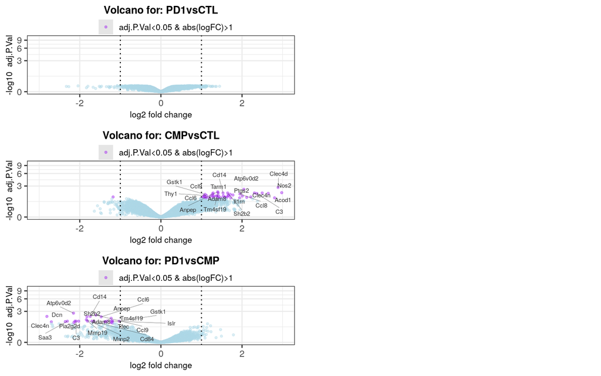

```r
dea.results <- dea_all(data=eset_analysis, targets=pData(eset_analysis), sampleNames="ShortName", group=design.mainfact, cov.fact=design.cofact, cov.num=design.num, fmla=NULL, block.cor=blocking.fact, contrastsv=contrastsv, moderated=TRUE, padjust.method="fdr", html_report=FALSE, html_ntop=500, html_group="Group", B_thr=c(0), Pval_thr=c(0.01,0.05,0.1), adjPval_thr=c(0.01,0.05,0.15,0.25), logFC_thr=0, extended=TRUE, B_thr.e=c(0), Pval_thr.e=c(0.01,0.05,0.1), adjPval_thr.e=c(0.01,0.05,0.15,0.25), logFC_thr.e=c(0,0.5,1,1.5,2), dovolcanoplot=TRUE, volc_logFC=rep(1,length(contrastsv)), volc_pval=c(rep("adj.P.Val", length(contrastsv))), volc_pval.thr=rep(0.05, length(contrastsv)), volc_x0=rep(-3, length(contrastsv)), volc_x1=rep(+3, length(contrastsv)), volc_y0=rep(0, length(contrastsv)), volc_y1=rep(10, length(contrastsv)), n=6, cols=2, label="", summaryFN=resultsSummFN, outputDir=resultsDir)
```

```r
names(dea.results)
```

```
## [1] "fit"             "fit.main"        "listofcsv"       "numGenesChanged"
```

```r
dea.results$fit.main$design
```

```
##       CTL PD1 CMP Batch2
## CTL.1   1   0   0      0
## CTL.2   1   0   0      1
## CTL.3   1   0   0      0
## CTL.4   1   0   0      1
## PD1.1   0   1   0      0
## PD1.2   0   1   0      1
## PD1.3   0   1   0      0
## PD1.4   0   1   0      1
## CMP.1   0   0   1      0
## CMP.3   0   0   1      0
## CMP.4   0   0   1      1
## attr(,"assign")
## [1] 1 1 1 2
## attr(,"contrasts")
## attr(,"contrasts")$Group
## [1] "contr.treatment"
##
## attr(,"contrasts")$Batch
## [1] "contr.treatment"
```

```r
dea.results$fit.main$contrasts
```

```
##         Contrasts
## Levels   PD1vsCTL CMPvsCTL PD1vsCMP
##   CTL          -1       -1        0
##   PD1           1        0        1
##   CMP           0        1       -1
##   Batch2        0        0        0
```

```r
#extract objects for further analysis:
fit.main <- dea.results$fit.main
listofcsv <- dea.results$listofcsv
numGenesChanged_all <- dea.results$numGenesChanged
```

```r
save(listofcoef, listofcsv, eset_norm, eset_analysis, targets, file=file.path(dataDir,"afterTopTabs.Rda"), version=2)
```

## 3.4 Block 03 Analysis of Multiple Comparisons

### 3.4.1 Background

It is interesting to look for common patterns of regulation between different experimental conditions. In order to find the degree of overlapped genes among different comparisons, a multiple comparisons analysis has been performed. Venn diagrams and heatmaps have been plotted for the different multiple comparisons.

### 3.4.2 Load the parameters for MC analysis and set directories

```r
#Parameters
source(file.path(paramDir, "03-MC.par"))
#Execution parameters
source(file.path(paramDir, "03-MC_analysistodo.par"))
```

For this example study, parameters were set as follows:

```r
(loadMC_parameters <- read.table(file.path(paramDir, "03-MC.par"), header = FALSE, sep=";", as.is=TRUE))
```

```
##                                                                                          V1
## 1                                                                        dataDirN <- dades
## 2                                                                   resultsDirN <- results
## 3                                                   resultsSummFN <- ResultsSummary_MC.txt
## 4                                                           inputMCRda <- afterTopTabs.Rda
## 5                                                   venn_comparNames <- c(EffectTreatment)
## 6                                                                 venn_compar <- list(1:3)
## 7                                                                venn_pval <- c(adj.P.Val)
## 8                                                                 venn_pval.thr <- c(0.05)
## 9                                                                       venn_logFC <- c(1)
## 10                                                               venn_include <- list(abs)
## 11                                                           venn_pos = list(c(0, 0, 180))
## 12
## 13                                                                    colFeat = Gene.Symbol
## 14                                                                      venn_FC_col = logFC
```

[output cut: 18 more lines]

```r
(loadMC_todoparameters <- read.table(file.path(paramDir, "03-MC_analysistodo.par"), header = FALSE, sep=";", as.is=TRUE))
```

```
##                                   V1
## 1                Venn_plots <- TRUE
## 2 Venn_sharedElems_extended <- TRUE
## 3             Heatmap_plots <- TRUE
## 4      hm_plots_interactive <- TRUE
```

Since directories could change from block to block, we set them again for this block:

```r
dataDir <- file.path(workingDir, dataDirN)
resultsDir <- file.path(workingDir, resultsDirN)
rdaDir <- dataDir
```

### 3.4.3 Data for MC

The Rda file generated in *Block 02-Differential Expression Analysis (DEA)* will be used as input for MC:

```r
load(file.path(dataDir, inputMCRda))
```

### 3.4.4 MC Venn Upset

Function `mc_venn_upset()` can be used to perform Venn diagrams and/or Upset plots for the comparisons analyzed.

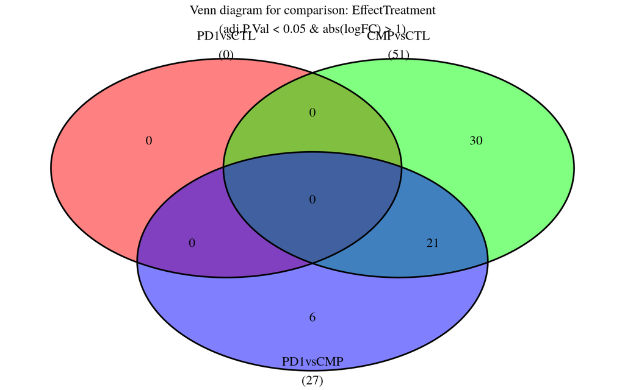

```r
listsharedelems <- lapply(seq_along(venn_comparNames), function(v) {
  setwd(resultsDir)
  namescomp <- names(listofcsv)[venn_compar[[v]]]
  listsharedelems <- mc_venn_upset(listofcsv=listofcsv, namescomp=namescomp, label = venn_comparNames[v], colFeat = colFeat[v],
                            colPval = venn_pval[v], pval = venn_pval.thr[v], colFC=venn_FC_col[v], FC=venn_FC.thr[v], include=venn_include[v], pltR = TRUE,
                            pltPdf = TRUE, pltPng=FALSE, venn = TRUE, eul = FALSE, saveTables = TRUE, upsetPlot=FALSE,
                            saveTables_extended=Venn_sharedElems_extended,
                            colors = rainbow(length(namescomp)), trans = 0.5,
                            cex1 = 1, rotation=0, position=venn_pos[[v]], cex2 = 1, resultsSummFN=resultsSummFN, outputDir=resultsDir)
  setwd(workingDir)
  return(listsharedelems)
})
```

```r
names(listsharedelems) <- venn_comparNames
```

```r
knitr::include_graphics(file.path(resultsDir, "VennDiagram.abs.EffectTreatment.adj.P.Val0.05.logFC1.pdf"))
```

[figure not shown]

### 3.4.5 MC Heatmap plots

Function `mc_hm()` can be used to perform Heatmap plots for the comparisons analyzed.

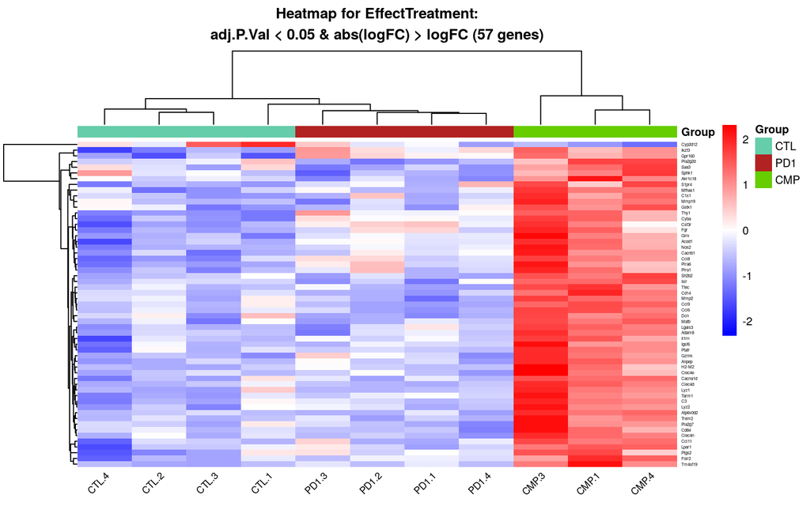

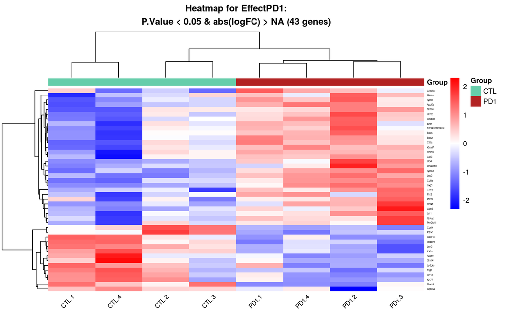

```r
mc_hm(listofcsv=listofcsv, hm_dataset=listofcsv[[1]], targets=targets.f, featureCol=featureCol, hm_comparNames=hm_comparNames, hm_compar=hm_compar, hm_groupexclude=hm_groupexclude, hm_pval=hm_pval, hm_pval.thr=hm_pval.thr, hm_logFC=hm_logFC, hm_logFC.thr=hm_logFC.thr, hm_palette=hm_palette, hm_clustCol=hm_clustCol, hm_clustCol.dist=hm_clustCol.dist, hm_clustCol.method=hm_clustCol.method, hm_clustRow.cor=hm_clustRow.cor, batcheffect=batcheffect, batchcolName=batchcolName, batchcolName2=batchcolName2, batchNumcolName=batchNumcolName, hm_plots_interactive=TRUE, resultsSummFN=resultsSummFN, outputDir=resultsDir)
```

## 3.5 Block 04 A-Analysis of Biological Significance (ABS-GSEA)

### 3.5.1 Background

The analysis of biological significance has been based on gene set enrichment analysis (GSEA) @Subramanian2005 on different annotation databases. The analysis has been performed over two annotation databases: the "Gene Ontology" (GO) and the Reactome Pathway Knowledge base @reactome:2018. The goal of this analysis is to perform one of the available statistical tests to determine whether a given *Gene Set*, usually a particular category of the GO or pathway in Reactome, is over-represented in the list of selected genes (the *sample*) with respect (i.e. compared) to a reference set (the *population*) from where it has been selected. The reference set is usually taken to be all the genes analyzed in the study. In GSEA, all the genes analyzed in the study ( *filtered genes*) are ranked by log fold change an used in the analysis. GSEA aggregates the per gene statistics across genes within a gene set, therefore making it possible to detect situations where all genes in a predefined set change in a small but coordinated way @Subramanian2005.

### 3.5.2 Load the parameters for ABS-GSEA and set directories

```r
#Parameters
source(file.path(paramDir, "04-ABS-GSEA.par"))
#Execution parameters
source(file.path(paramDir, "04-ABS-GSEA_analysistodo.par"))
```

For this example study, parameters were set as follows:

```r
(loadABSGSEA_parameters <- read.table(file.path(paramDir, "04-ABS-GSEA.par"), header = FALSE, sep=";", as.is=TRUE))
```

```
##                                                                  V1
## 1                                                dataDirN <- dades
## 2                                           resultsDirN <- results
## 3                     resultsSummFN <- ResultsSummary_ABS-GSEA.txt
## 4                              inputABSGSEARda <- afterTopTabs.Rda
## 5                 annotPackage <- clariomsmousetranscriptcluster.db
## 6                                  organism_annot  <- org.Mm.eg.db
## 7                                                organism <- mouse
## 8                                                            label=
## 9                      resultsSummFN <- ResultsSummary_ABS-GSEA.txt
## 10                                          ranking_metric <- logFC
## 11                                          geneColname <- EntrezID
## 12                                             keyType <- ENTREZID
## 13                                                        label <-
## 14                                                readable <- FALSE
## 15                                                  saveGMT <- TRUE
## 16                                               saveTables <- TRUE
## 17                                                  saveRda <- TRUE
## 18                                        GO_comparisons <- c(1:3)
## 19 GO_pvalcutoff <- list(rep(0.05, 3), rep(0.05, 3), rep(0.05, 3))
## 20    GO_pAdjustMethod <- list(rep(BH, 3), rep(BH, 3), rep(BH, 3))
## 21                                              GO_minSetSize <- 3
## 22                                            GO_maxSetSize <- 500
## 23                              Reac_comparisons <- GO_comparisons
## 24                                 Reac_pvalcutoff <- rep(0.05, 3)
## 25                                Reac_pAdjustMethod <- rep(BH, 3)
## 26                                            Reac_minSetSize <- 3
## 27                                          Reac_maxSetSize <- 500
```

```r
(loadABSGSEA_todoparameters <- read.table(file.path(paramDir, "04-ABS-GSEA_analysistodo.par"), header = FALSE, sep=";", as.is=TRUE))
```

```
##                                             V1
## 1                          GOAnalysis <- TRUE
## 2             GOAnalysis.unfilt <- GOAnalysis
## 3               GOAnalysis.filt <- GOAnalysis
## 4                             GOPlots <- TRUE
## 5             GO_categories <- list(BP,CC,MF)
## 6                     ReactomeAnalysis <- TRUE
## 7 ReactomeAnalysis.unfilt <- ReactomeAnalysis
## 8   ReactomeAnalysis.filt <- ReactomeAnalysis
## 9                        ReactomePlots <- TRUE
```

Since directories could change from block to block, we set them again for this block:

```r
dataDir <- file.path(workingDir, dataDirN)
resultsDir <- file.path(workingDir, resultsDirN)
rdaDir <- dataDir
gmtDir <- resultsDir
```

### 3.5.3 Data for ABS-GSEA

The Rda file generated in *Block 02-Differential Expression Analysis (DEA)* will be used as input for GSEA:

```r
load(file.path(dataDir, inputABSGSEARda))
```

### 3.5.4 GO unfilt GSEA

Function `abs_gsea_GOunfilt()` can be used to perform GO analysis for all the comparisons and store unfiltered results (no pvalue threshold) in lists. The necessary inputs are the toptables generated in the DEA analysis and as output, the analysis will give you lists of GO unfiltered results and a table with number of terms found at different pvalue thresholds for the different categories analyzed.

```r
namescomp <- names(listofcsv)[GO_comparisons]
```

```r
GSEA_GOresults.unfilt <- abs_gsea_GOunfilt(listofTopNamed=listofcsv, namescomp=namescomp, annotPackage=annotPackage, organism_annot= organism_annot, ranking_metric=ranking_metric, geneColname=geneColname, keyType=keyType, GO_minSetSize=GO_minSetSize, GO_maxSetSize=GO_maxSetSize, resultsSummFN=resultsSummFN, saveRda=saveRda, saveGMT=saveGMT, label=label, outputDir=resultsDir, rdaDir=rdaDir, gmtDir=gmtDir)
```

### 3.5.5 GO filt GSEA plots

Function `abs_gsea_GOfiltplot()` filters GO results according to the pvalue threshold set previously in parameters. It takes as input the lists of GO unfiltered results and pvalue thresholds. As an output, dataframes of GO results filtered by pvalue are obtained. The function also performs a GO significance analysis, giving some plots with the most enriched GO terms pathways.

```r
GSEA_GOresults.filt <- abs_gsea_GOfiltplot(GSEAresGO=GSEA_GOresults.unfilt, GO_pvalcutoff=GO_pvalcutoff, GO_pAdjustMethod=GO_pAdjustMethod, saveTables=saveTables, GOPlots=GOPlots, label=label, resultsSummFN=resultsSummFN, outputDir=resultsDir)
```

### 3.5.6 Reactome pathways unfilt GSEA

Function `abs_gsea_ReactomePAunfilt()` can be used to perform Reactome analysis for all the comparisons and store unfiltered results (no pvalue threshold) in lists. The necessary inputs are the toptables generated in the DEA analysis and as output, the analysis will give you lists of Reactome unfiltered results and a table with number of terms found at different pvalue thresholds for the different categories analyzed.

```r
namescomp <- names(listofcsv)[Reac_comparisons]
GSEA_ReactomePA.unfilt <- abs_gsea_ReactomePAunfilt(listofTopNamed=listofcsv, namescomp=namescomp, organism=organism, organism_annot=organism_annot, Reac_minSetSize=Reac_minSetSize, Reac_maxSetSize=Reac_maxSetSize, resultsSummFN=resultsSummFN, saveRda=saveRda, saveGMT=saveGMT, label=label, outputDir=resultsDir, rdaDir=rdaDir, gmtDir=gmtDir)
```

### 3.5.7 Reactome filt GSEA plots

Function `abs_gsea_ReactomePAfiltplot()` filters Reactome results according to the pvalue threshold set previously in parameters. It takes as input the lists of Reactome unfiltered results and pvalue thresholds. As an output, dataframes of Reactome results filtered by pvalue are obtained. The function also performs a Reactome significance analysis, giving some plots with the most enriched Reactome pathways.

```r
abs_gsea_ReactomePAfiltplot(GSEAresReac=GSEA_ReactomePA.unfilt, Reac_pvalcutoff=Reac_pvalcutoff, Reac_pAdjustMethod=Reac_pAdjustMethod, saveTables=saveTables, ReacPlots=ReactomePlots, label=label, resultsSummFN=resultsSummFN, outputDir=resultsDir)
```

## 3.6 Block 04 B-Analysis of Biological Significance (ABS-ORA)

### 3.6.1 Background

An overrepresentation analysis (ORA) will be performed over GO-BP and Reactome Pathways databases to find the terms enriched in the lists of genes up-regulated/down-regulated in common between the comparisons analyzed.

### 3.6.2 Load the parameters for ABS-ORA and set directories

```r
#Parameters
source(file.path(paramDir, "04-ABS-ORA.par"))
#Execution parameters
source(file.path(paramDir, "04-ABS-ORA_analysistodo.par"))
```

For this example study, parameters were set as follows:

```r
(loadABSORA_parameters <- read.table(file.path(paramDir, "04-ABS-ORA.par"), header = FALSE, sep=";", as.is=TRUE))
```

```
##                                                                             V1
## 1                                                           dataDirN <- dades
## 2                                                      resultsDirN <- results
## 3                                 resultsSummFN <- ResultsSummary_ABS-ORA.txt
## 4                                          inputABSORARda <- afterTopTabs.Rda
## 5                          annotPackage <- clariomsmousetranscriptcluster.db
## 6                                             organism_annot  <- org.Mm.eg.db
## 7                                                           organism <- mouse
## 8                                                                       label=
## 9                                  resultsSummFN <- ResultsSummary_ABS-ORA.txt
## 10                                                           universe <- NULL
## 11                                                            sign <- c(1,-1)
## 12                                                         keyType <- ENTREZID
## 13                                                    geneColname <- EntrezID
## 14                                                   GO_categories <- list(BP)
```

[output cut: 22 more lines]

```r
(loadABSORA_parameters <- read.table(file.path(paramDir, "04-ABS-ORA_analysistodo.par"), header = FALSE, sep=";", as.is=TRUE))
```

```
##                                              V1
## 1                              readable <- TRUE
## 2                               saveGMT <- TRUE
## 3                            saveTables <- TRUE
## 4                               saveRda <- TRUE
## 5                           GOAnalysis <- TRUE
## 6              GOAnalysis.unfilt <- GOAnalysis
## 7                GOAnalysis.filt <- GOAnalysis
## 8                              GOPlots <- TRUE
## 9              GO_categories <- list(BP,CC,MF)
## 10                     ReactomeAnalysis <- TRUE
## 11 ReactomeAnalysis.unfilt <- ReactomeAnalysis
## 12   ReactomeAnalysis.filt <- ReactomeAnalysis
## 13                        ReactomePlots <- TRUE
```

Since directories could change from block to block, we set them again for this block:

```r
dataDir <- file.path(workingDir, dataDirN)
resultsDir <- file.path(workingDir, resultsDirN)
rdaDir <- dataDir
gmtDir <- resultsDir
```

### 3.6.3 Data for ABS-ORA

The Rda file generated in *Block 02-Differential Expression Analysis (DEA)* will be used as input for ABS-ORA:

```r
load(file.path(dataDir, inputABSORARda))
```

### 3.6.4 GO unfilt ORA

Function `abs_ora_GOunfilt()` can be used to perform an overrepresentation GO analysis for all the comparisons and store unfiltered results (no pvalue threshold) in lists. The necessary inputs are the toptables generated in the DEA analysis and as output, the analysis will give you lists of GO unfiltered results and a table with number of terms found at different pvalue thresholds for the different categories analyzed.

```r
ORA_GOresults.unfilt <- abs_ora_GOunfilt(listofTopNamed=listofcsv, namescomp=namescomp, universe=universe, geneColname=geneColname, readable=readable, selected.pval.go=selected.pval.go, selected.pvalthr.go=selected.pvalthr.go, selected.logFC.go=selected.logFC.go, col_logFC.go=col_logFC.go, sign_logFC.go=sign_logFC.go, organism_annot=organism_annot, keyType=keyType, GO_categories=GO_categories, GO_minSetSize=GO_minSetSize, GO_maxSetSize=GO_maxSetSize, resultsSummFN=resultsSummFN, saveRda=saveRda, saveGMT=saveGMT, label=label, outputDir=resultsDir, rdaDir=rdaDir, gmtDir=gmtDir)
```

### 3.6.5 GO filt ORA plots

Function `abs_ora_GOfiltplot()` filters GO results according to the pvalue threshold set previously in parameters. It takes as input the lists of GO unfiltered results and pvalue thresholds. As an output, dataframes of GO results filtered by pvalue are obtained. The function also performs a GO significance analysis, giving some plots with the most enriched GO terms pathways.

```r
ORA_GOresults.filt <- abs_ora_GOfiltplot(ORAresGO=ORA_GOresults.unfilt, sign=sign, GO_pvalcutoff=GO_pvalcutoff, GO_pAdjustMethod=GO_pAdjustMethod, saveTables=saveTables, GOPlots=GOPlots, label=label, resultsSummFN=resultsSummFN, outputDir=resultsDir)
```

### 3.6.6 Reactome unfilt ORA

Function `abs_ora_ReactomePAunfilt()` can be used to perform an overrepresentation Reactome analysis for all the comparisons and store unfiltered results (no pvalue threshold) in lists. The necessary inputs are the toptables generated in the DEA analysis and as output, the analysis will give you lists of Reactome unfiltered results and a table with number of terms found at different pvalue thresholds for the different categories analyzed.

```r
ORA_ReactomePAresults.unfilt <- abs_ora_ReactomePAunfilt(listofTopNamed=listofcsv, namescomp=namescomp, universe=universe, col_entrez=col_entrez, readable=readable, selected.pval.reac=selected.pval.reac, selected.pvalthr.reac=selected.pvalthr.reac, selected.logFC.reac=selected.logFC.reac, col_logFC.reac=col_logFC.reac, sign_logFC.reac=sign_logFC.reac, organism=organism, organism_annot=organism_annot, keyType=keyType, Reac_minSetSize=Reac_minSetSize, Reac_maxSetSize=Reac_maxSetSize, resultsSummFN=resultsSummFN, saveRda=saveRda, saveGMT=saveGMT, label=label, outputDir=resultsDir, rdaDir=rdaDir, gmtDir=gmtDir)
```

### 3.6.7 Reactome filt ORA plots

Function `abs_ora_ReactomePAfiltplot()` filters Reactome results according to the pvalue threshold set previously in parameters. It takes as input the lists of Reactome unfiltered results and pvalue thresholds. As an output, dataframes of Reactome results filtered by pvalue are obtained. The function also performs a Reactome significance analysis, giving some plots with the most enriched Reactome pathways.

```r
ORA_ReactomePAanalysis_filt <- abs_ora_ReactomePAfiltplot(ORAresReac=ORA_ReactomePAresults.unfilt, sign=sign, Reac_pvalcutoff=Reac_pvalcutoff, Reac_pAdjustMethod=Reac_pAdjustMethod, saveTables=saveTables, ReacPlots=ReacPlots, label=label, resultsSummFN=resultsSummFN, outputDir=resultsDir)
```

# 4 References